# Project 2: Ebolaviruses Nucleoprotein

# **Introduction**

**Scientific Question:** What are the genetic differences, in terms of DNA sequences and protein structures of the nucleoprotein common to ebolaviruses, between the Tai Forest ebolavirus and Bundibugyo ebolavirus that originated in Africa as well as the Reston ebolavirus found in the Philippines?

**Background:** Ebolavirus, also called ebola hemorrhagic fever, is a rare deadly virus that can infect humans and has no cure (Feldmann & Geisbert, 2011). There are currently five species of Ebolavirus. Zaire ebolavirus is the most common one with the highest case-fatality rate. Sudan ebolavirus, Tai Forest ebolavirus, and Bundibugyo ebolavirus are also species that have affected humans. Only the Reston ebolavirus, which is also the only ebolavirus to have originated in the Philippines and not Africa, was found in animals without any affect on humans (Patel & Patel, 2016).

All ebolaviruses share similar structures, including the nucleoprotein which plays a central role in virus replication (Huang et al., 2002). In a previous article, it has been discovered that the nucleoproteins of a few marburgviruses are highly similar to that of ebolaviruses (Baker et al., 2016). Two pdb files from this article will be used for our scientific question. Whereas they focused on comparing ebolaviruses to marburgviruses, I am going to compare specific species of ebolaviruses.

**Hypothesis:** If the Tai Forest ebolavirus and Bundibugyo ebolavirus both arose in Africa and developed under similar conditions to infect humans, then there would be more similarities in the DNA sequences and protein structure of the nucleoprotein between them than with the Reston ebolavirus from the Philippines that does not affect humans.

To address this scientific question we will first perform multiple sequence alignment on the original fasta files for the nuecleoprotein of the three Ebolaviruses. From that result we decide on a smaller, more specific sequence that is then visualized via sequence logos. By comparing sequence logos, we can determine which two ebolaviruses are more similar in terms of DNA sequences. To compare protein structures we first trim out just the chain A of every Ebolavirus pdb file and display them using NGLVieweR. Then we calculate the RMSD values and visualize them via hierarchical clusetering. The cluster depicts which two Ebolaviruses are more similar in terms of protein structure.

### Definition of each package loaded:

1. BiocManager
2. Biostrings
3. msa
4. phylotools
5. ggplot2
6. ggseqlogo
7. bio3d
8. muscle
9. NGLVieweR

Note: will be calling to each package within chunks in code using the require() function to indicate what package is needed for which method - this is not necessary for code to run if everything is loaded at the beginning

Loading Packages.

```r
##Uncomment code to install anything you don't have. Call them all via library() function

library(BiocManager)
library(Biostrings)
# if (!requireNamespace("BiocManager", quietly=TRUE))
#     install.packages("BiocManager")
# BiocManager::install("msa")
library(msa)
```

```r
#install.packages("phytools",repos="https://cloud.r-project.org",quiet=TRUE)
library(phylotools)
#install.packages("ggplot2")
library(ggplot2)
#install.packages("ggseqlogo")
library(ggseqlogo)
#install.packages("bio3d", dependencies=TRUE)
library(bio3d)
# if (!require("BiocManager", quietly = TRUE))
#     install.packages("BiocManager")
# BiocManager::install("muscle")
library(muscle)
#install.packages("NGLVieweR")
library(NGLVieweR)
```

**Global vs Local Variables:** A global variable can be accessed in the entire program while local variables can only be accessed within the function it was defined in. Within my code my global variables will be indicated via the comment “global” and my local variables will be indicated via the comment “local”.

# **Part 1: Multiple Sequence Alignment and Sequence Logo**

**Multiple Sequence Alignment(MSA)** is a bioinformatic method that is able to align three or more biological sequences with similar lengths. NCBI provided the fasta files for the nucleotide sequence of the nucleoprotein of: * the Reston Ebolavirus *(Gene ID: 955194 ; Sequence: NC_004161.1)* * the Tai Forest Ebolavirus *(Gene ID: 9487539 ; Sequence: NC_014372.1)* * Bundibugyo Ebolavirus *(Gene ID: 9487269 ; Sequence: NC_014373.1)*

We begin by calling in the fasta files that were downloaded. To generate multiple sequence alignment, we first need to make XStringSet objects that can then be aligned. The result is a complete alignment of the three sequences, with a consensus sequence that represents that alignment.

```r
#to perform a MSA need this package
require(msa)

#call in all the fasta files for each Ebolavirus and combining them into a single vector
#global
Ebola_seq_NP <- c("C:/Users/Elizabeth/Documents/BIMM143-S22/data_project_2/reston_NP.fasta", "C:/Users/Elizabeth/Documents/BIMM143-S22/data_project_2/tai_forest_NP.fasta", "C:/Users/Elizabeth/Documents/BIMM143-S22/data_project_2/bundibugyo_NP.fasta")

#Read the files into an XStringSet object
#global
Ebola_seq_unaligned <- readAAStringSet(Ebola_seq_NP)
#check datatype - should be s4
typeof(Ebola_seq_unaligned)
```

```
## [1] "S4"
```

```r
#Perform Multiple sequence alignment using the msa(function) and assign it to a vector
#global
Ebola_NP <- msa(Ebola_seq_unaligned)
```

```
## use default substitution matrix
```

```r
#print the complete msa
print(Ebola_NP, show="complete")
```

```
##
## MsaAAMultipleAlignment with 3 rows and 2986 columns
##     aln (1..54)                                            names
## [1] GAGGAAGATTAATAATTTTCCTCTCATTGACACTTACATTAAGATTAAGATTCT NC_014372.1:56-30...
## [2] GAGGAAGATTAAAGATTTTCCTCTCATTGAAATTGAAATTGAGATTCTAATCTC NC_014373.1:56-30...
## [3] GAGGAAGATTAACAGTTTTCCTCAGTTTAAGATATACACTGAAATTGAGATTGA NC_004161.1:56-30...
## Con GAGGAAGATTAA?AATTTTCCTCTCATTGA?ATTTACATTGAGATT?AGATT?? Consensus
##
##     aln (55..108)                                          names
## [1] CATTGATCTGTTACTTACTCTGAGGATAATAATTGGTGTTCAGAAGTACCCCAT NC_014372.1:56-30...
## [2] GACGGATCGATCCCCAATACCAACACTGAGAATTGGCCTGAAGAAGTCATCTGC NC_014373.1:56-30...
## [3] GATTCTCCTCTTTGCTATTCTGTAACTTTCCCTGGTTGTGACAATTGAATCAGT NC_004161.1:56-30...
## Con GATTGATCT?TT?CCTATTCTGA?ACT?A?AATTGGTGTGAAGAAGTAATC?GT Consensus
##
##     aln (109..162)                                         names
## [1] TCCCCAGTGGGGGCAAAGACAGTCCAAAAGACTCAACTTGTCCTATT----CAA NC_014372.1:56-30...
## [2] TCCTTGGCAAAACCAAGAGCAGGCCCAAAGGG-CCATTAGGCCACAT----CTG NC_014373.1:56-30...
## [3] TTTATC-TATTACCAATTACCATCAACATGGTATGTCTAGTGATCTTGGGACTC NC_004161.1:56-30...
## Con TCC?T?GTA??ACCAA??ACAGTCCAAAAGG??C?ACTAGTCCTCTT----CT? Consensus
##
##     aln (163..216)                                         names
## [1] CTAATCTGTTTTGTCTCAGTAGTTCACATATTGATCATACCCAGGAGTTGGACC NC_014372.1:56-30...
## [2] CTGAGCCTGCAGAACACGCAGG---ACTTACTTAGCAGAAGAGAGCGCGTGCCG NC_014373.1:56-30...
## [3] TTCTTCATCTGGTTTTTCCTAGAGCTCTGAATCCATTTTGCGAGAAGTTCATCC NC_004161.1:56-30...
## Con CT?ATC?T?T?G?TCTC?CTAG??CACTTA?T?A?CATA?C?AGGAGTT?G?CC Consensus
##
##     aln (217..270)                                         names
## [1] TAATTCCAAAGCTTAGAGTGGGACCTAGTGTATCCTCGGGGCTGTAATATAATC NC_014372.1:56-30...
## [2] AAA---CCAGCCAACAAATTGACACAGCTGCTCACTCTGACCCTGAATTCATAA NC_014373.1:56-30...
## [3] AAACGACCCAGTGTCTGAAAATACAAAAGGTTCCCCTTTCCGTCAAGTTTAAGG NC_004161.1:56-30...
## Con AAA???CCAAGC?TC?AAT?G?ACCAA?TGTTCCCTCTG?CCT??AATTTAA?? Consensus
##
##     aln (271..324)                                         names
## [1] AGCCATTTAACACATAACAAGCCCTACTGTTTTCTTGTTTTG-CCGTGCATTTA NC_014372.1:56-30...
## [2] ACAATATTAAGTTGACAACAGAGATACTAATCCAATATTTGGATCAAGAATCAA NC_014373.1:56-30...
## [3] GGTTGTTTTGATTGTGTGTAGATTTTATAATCCTAGAG--TGCCAAGGAGTTGC NC_004161.1:56-30...
## Con AG???TTTAA?TTGT?A??AGA??TACTAATCC?ATATTTTG?CCA?GAATT?A Consensus
##
##     aln (325..378)                                         names
## [1] GAATAAGAGACAACT---TAAACCTCCGATTCGGCAACACAGGGAATAATCTCA NC_014372.1:56-30...
```

[output cut: 282 more lines]

```
## [2] AGAAGCACCACCCCATAACAACAACCCCAAACCAACAACACTGCATGTAAGTAT NC_014373.1:56-30...
## [3] GGGATAAATAATACTTTATATTTCTGATTGTGGATTGACCCATTCTGCTTAAAA NC_004161.1:56-30...
## Con ?GAA?CACCACCCCATTACA??A?CCC??A?C?AAC?AC?C??CATGCAAG?A? Consensus
##
##     aln (2917..2970)                                       names
## [1] CCCACCCATCCCAGAAACCGCACGGCCGAGAATCGATCCCCAGCATTCAAAATG NC_014372.1:56-30...
## [2] TGTCTCACCCCAAGATGATCCCTGGACACCAACAACCCCCTAACCTCCCCAAGT NC_014373.1:56-30...
## [3] TGCTTCGCCCATTGAAAATG--TGATCTAATAGATAGCCCTGACTAGACAAA-- NC_004161.1:56-30...
## Con TGC?TC?CCCC?AGAAAATGC?TGG?C?A?AA?A?A?CCCTAAC?T?CCAAA?? Consensus
##
##     aln (2971..2986)  names
## [1] CGTTATTAAGAAAAAA NC_014372.1:56-30...
## [2] TGTCATTAAGAAAAAA NC_014373.1:56-30...
## [3] -----TTAAGAAAAA- NC_004161.1:56-30...
## Con ?GT?ATTAAGAAAAAA Consensus
```

From the MSA results of the whole nucleoprotein, needed to select a specific smaller part of code to inspect via Sequence Logos. I decided to look at the section 397-468 because the consensus sequence there had a lot of variety. Went into the MSA results and literally copy/pasted the code. Can perform this with any section of code as long as its not over 100 nucleotides.

```r
#need phylotools for this
require(phylotools)

#use the cat() function to concatenate the sequences we chose to focus on
#tf is tai forest, b is bundibugyo, r is reston
#give the  fasta file a name
cat(">seq_1_tf", "TCAGGCTTCATAGCCCCAAGATGGAGAGTCGGGCCCACAAAGCATGGATGACGCACACCGCATCAGGTTTCG", ">seq_2_b", "TCTCTATCCAAGACCTCAAAATGGATCCTCGTCCAATCAGAACCTGGATGATGCATAACACATCTGAAGTTG",
">seq_3_r", "TCGAACAAGGGGAAGTCGATATGGATCGTGGGACCAGAAGAATCTGGGTGTCGCAAAATCAAGGTGATACTG",
file = "ebola_trim.fasta", sep = "\n")

#asign the fasta file to a vector
#global
fasta <- read.fasta("ebola_trim.fasta")
#function dat2fasta() saves file in working directory
dat2fasta(fasta)
```

```
## out.fasta has been saved to  C:/Users/Elizabeth/Documents/BIMM143-S22
```

```r
#now we want to split the dataframe of sequences into groups
#in this case the seq_1_tf is group 1, the seq_2_b is group 2, and the seq_3_r is group 3
sequence_name <- get.fasta.name("ebola_trim.fasta")
sequence_group <- c("group1","group2","group3")
group <- data.frame(sequence_name, sequence_group)

#split the data and it will save to working directory
#had to comment this part out because you cant download these files multiple times. All the files will be included in the GitHub page as proof that the code did work

#split_dat(fasta, group)

#check dataframe
print(group)
```

```
##   sequence_name sequence_group
## 1      seq_1_tf         group1
## 2       seq_2_b         group2
## 3       seq_3_r         group3
```

**Sequence Logo** is a graphic representation of the conservation of sequences of either nucleotides or amino acids. The usual method of using sequence logos is to generate it based on the all the sequences in the MSA at the same time. The sequence logo contains a stack of letters at each position and the size of the letters indicate how often they appear in the sequences. The larger/taller the letters are, the more representative that position of alignment is. Ex: large ATG indicates most if not all sequences had ATG in that position. This visualization method helps determine what the conserved domains are.

However, the goal for this question/hypothesis is to compare similarity/differences between the three sequences rather than to determine the conserved domains. As such I will be generating 3 sequence logos that compare two sequences at a time. Because there are only two sequences being compared, we will not see stacks of letters and instead, any tall letters indicate the shared nucleotide at that position. The more tall letters exist, the more similar the two sequences are.

Sequence logos are performed on a MSA vector so we first need to call in the fasta files we created previously of the short sequence and run a MSA again.

```r
#call in short fasta files into a single vector
#reminder: group 1 = tai forest ; group 2 = bundibugyo ; group 3 = reston
#global
Ebola_trim <- c("C:/Users/Elizabeth/Documents/BIMM143-S22/data_project_2/group1.fasta", "C:/Users/Elizabeth/Documents/BIMM143-S22/data_project_2/group2.fasta", "C:/Users/Elizabeth/Documents/BIMM143-S22/data_project_2/group3.fasta")

#Read the files into an XStringSet object
#global
Ebola_trim_unaligned <- readAAStringSet(Ebola_trim)
#check datatype - should be s4
typeof(Ebola_trim_unaligned)
```

```
## [1] "S4"
```

```r
#Perform Multiple sequence alignment using the msa(function) and assign it to a vector
#global
trim_aligned <- msa(Ebola_trim_unaligned)
```

```
## use default substitution matrix
```

```r
#print the complete msa
print(trim_aligned, show="complete")
```

```
##
## MsaAAMultipleAlignment with 3 rows and 72 columns
##     aln (1..54)                                            names
## [1] TCAGGCTTCATAGCCCCAAGATGGAGAGTCGGGCCCACAAAGCATGGATGACGC seq_1_tf
## [2] TCTCTATCCAAGACCTCAAAATGGATCCTCGTCCAATCAGAACCTGGATGATGC seq_2_b
## [3] TCGAACAAGGGGAAGTCGATATGGATCGTGGGACCAGAAGAATCTGGGTGTCGC seq_3_r
## Con TC???CT?CA?GACCTCAA?ATGGATCGTCGG?CCA?CAGAACCTGGATGACGC Consensus
##
##     aln (55..72)       names
## [1] ACACCGCATCAGGTTTCG seq_1_tf
## [2] ATAACACATCTGAAGTTG seq_2_b
## [3] AAAATCAAGGTGATACTG seq_3_r
## Con A?AAC?CATCTGAT?TTG Consensus
```

Perform Sequence Logo on the MSA of the trimmed section from the three Ebolavirus nucleoprotiens

```r
#to generate sequence logos need these two packages
require(ggplot2)
require(ggseqlogo)

#take the aligned vector and change it to characters.
#Assign characters to another vector that will be used to generate sequence logos
#global
algn_character <- as.character(trim_aligned)
#check that the vector is indeed characters
typeof(algn_character)
```

```
## [1] "character"
```

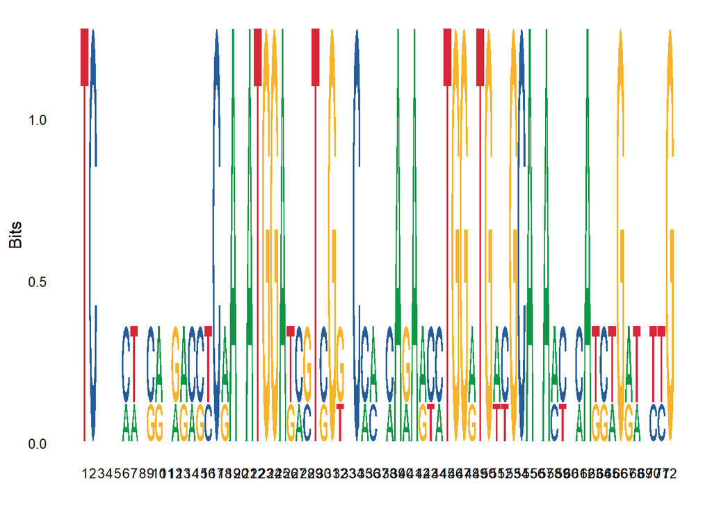

```r
#use the ggseqlogo() function to generate the following sequence logos:
#reminder that the 1 is tai forest, 2 is bundibugyo, and 3 is reston

#this is a sequence logo of all three sequences.
#this is just to check that the sequence logo works as intended and to see the general pattern of conservation between all three
#is not used to make any conclusions
ggseqlogo(algn_character)
```

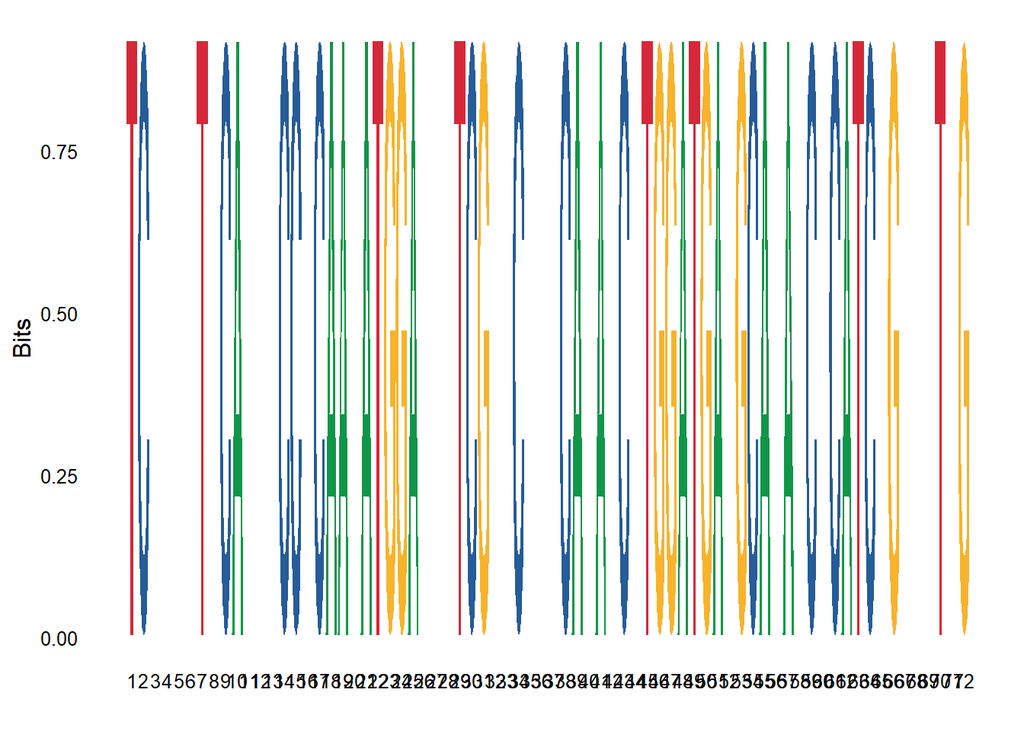

```r
#comparing tai forest and bundibugyo
ggseqlogo(algn_character[1:2])
```

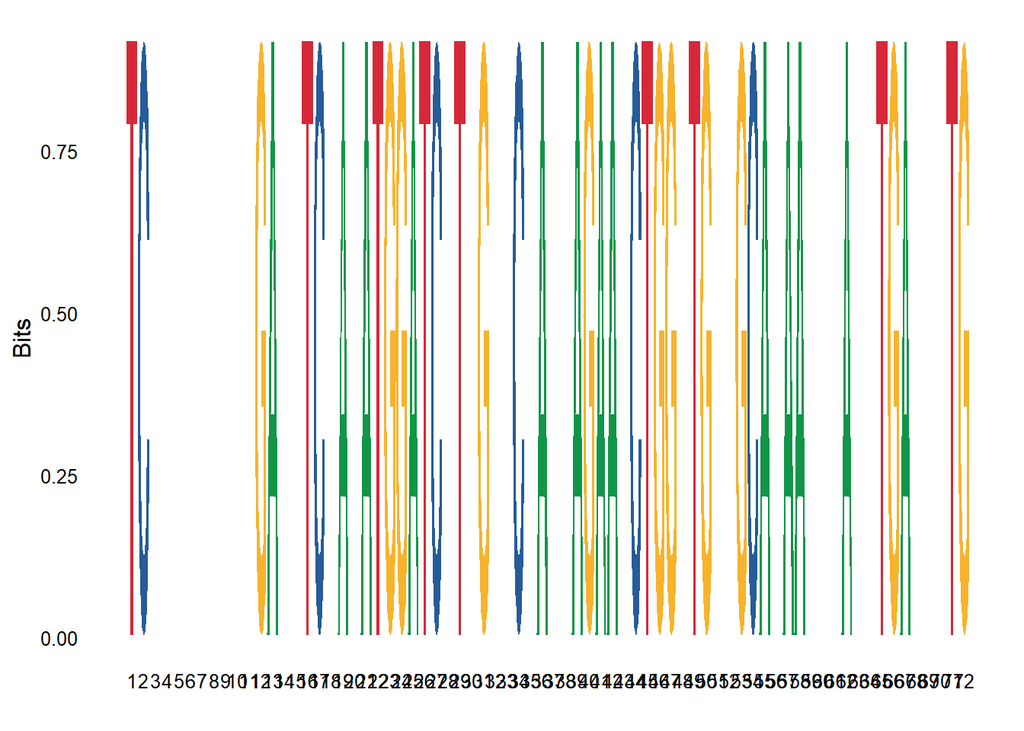

```r
#comparing bundibugyo and reston
ggseqlogo(algn_character[2:3])
```

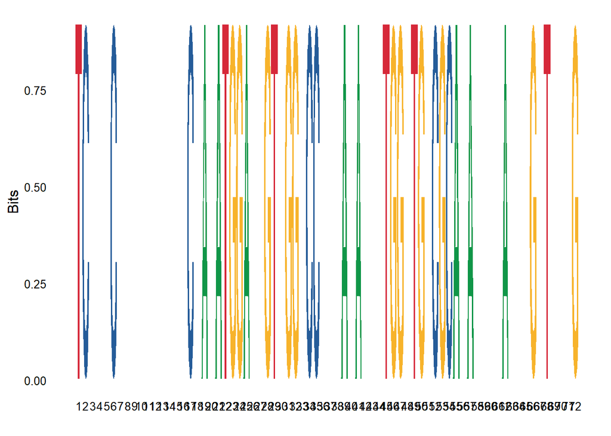

```r
#comparing tai forest and reston
ggseqlogo(algn_character[c(1,3)])
```

# **Part 2: RMSD of A chain of Nucleoprotein (C-Terminal Domain) and Hierarchical Clustering**

For part 2, we will be working with protein structures/pdb files. Used the PDB website to find the crystal structures of the C-terminal domain of the nucleoproteins of the three Ebolaviruses. Two of the structures came from the same paper (https://doi.org/10.1107/S2059798315021439) + Tai Forest - 5E2X + Bundibugyo - 5DSD

The other one is from a different unpublished paper + Reston - 5W2B

To account for any differences, we begin by first trimming the structures to focus on just their chain A and create new pdb files.

```r
#need one package to write new pdb
require(bio3d)

#read in pdb files from online database
#global
reston_pdb <- read.pdb('5w2b')
```

```
##   Note: Accessing on-line PDB file
```

```r
taiforest_pdb <- read.pdb('5e2x')
```

```
##   Note: Accessing on-line PDB file
##    PDB has ALT records, taking A only, rm.alt=TRUE
```

```r
bundibugyo_pdb <- read.pdb('5dsd')
```

```
##   Note: Accessing on-line PDB file
##    PDB has ALT records, taking A only, rm.alt=TRUE
```

```r
#to focus on just chain A of each nucleoprotein, use the trim.pdb() function and select just chain A of each pdb
#global
reston_a <- trim.pdb(reston_pdb, chain="A")
taiforest_a <- trim.pdb(taiforest_pdb, chain="A")
bundibugyo_a <- trim.pdb(bundibugyo_pdb, chain="A")

#create new pdbs for just chain A of each ebolavirus using the write.pdb() function. Name the files
write.pdb(reston_a, file="reston_a.pdb")
write.pdb(taiforest_a, file="taiforest_a.pdb")
write.pdb(bundibugyo_a, file="bundibugyo_a.pdb")
```

Image chain A of the Reston, Tai Forest, and Bundibugyo nucleoproteins to make sure the structures are visually similar

```r
#use NGLVieweR package to image the structures
require(NGLVieweR)

#Load chain A only pdb files into one vector
#global
proteins <- c("C:/Users/Elizabeth/Documents/BIMM143-S22/data_project_2/reston_a.pdb", "C:/Users/Elizabeth/Documents/BIMM143-S22/data_project_2/taiforest_a.pdb", "C:/Users/Elizabeth/Documents/BIMM143-S22/data_project_2/bundibugyo_a.pdb")

#create function for displaying the 3D structures
display <- function (x){
  #local
  print(NGLVieweR(x) %>%
  stageParameters(backgroundColor = "white", zoomSpeed = 1) %>%
  addRepresentation("cartoon",
    param = list(name = "cartoon", colorScheme = "residueindex")
  ))

}

#run function for all 3 proteins
for (i in 1:3){
  #local
  display(proteins[i])

}
```

**RMSD, or root-mean-square deviation,** is the standard measure of structural distance between coordinate sets. The smaller an RMSD value is, the more closely related the two structures are.

Find the RMSD values of chain A between all 3 structures.

```r
#packages needed:
require(bio3d)
require(msa)
require(muscle)

#combine the chain A pdb files into one vector
#global
files <- c("reston_a.pdb", "taiforest_a.pdb", "bundibugyo_a.pdb")

#align the files using the pdbaln() function.
#the exefile=msa part is needed to help run this because having just muscle installed via library(muscle) is not enough.
#global
pdbs <- pdbaln(files, exefile='msa')
```

```
## Reading PDB files:
## reston_a.pdb
## taiforest_a.pdb
## bundibugyo_a.pdb
## ..   PDB has ALT records, taking A only, rm.alt=TRUE
## .
##
## Extracting sequences
##
## pdb/seq: 1   name: reston_a.pdb
## pdb/seq: 2   name: taiforest_a.pdb
## pdb/seq: 3   name: bundibugyo_a.pdb
##    PDB has ALT records, taking A only, rm.alt=TRUE
```

```r
#Gap positions
inds <- gap.inspect(pdbs$xyz)

#Perform superposition before pairwise RMSD by setting fit=TRUE
rmsd(pdbs$xyz, fit=TRUE)
```

```
##              reston_a taiforest_a bundibugyo_a
## reston_a        0.000       2.850        0.839
## taiforest_a     2.850       0.000        2.383
## bundibugyo_a    0.839       2.383        0.000
```

```r
#perform RMSD between structure 1 and all the other structures in alignment
#global
rd <- rmsd(a=pdbs$xyz[1,], b=pdbs$xyz[2:3,], a.inds=inds$f.inds, b.inds=inds$f.inds, fit=TRUE)
```

**Hierarchical clustering** is an algorithm that groups similar data points into clusters. Usually displayed via a dendrogram, this tree diagram helps show which data is more similar to one another.

```r
# RMSD hierarchical clustering requires bio3d
require(bio3d)

#perform the simpler version of RMSD to call upon it
#global
rd <- rmsd(pdbs, fit=TRUE)
```

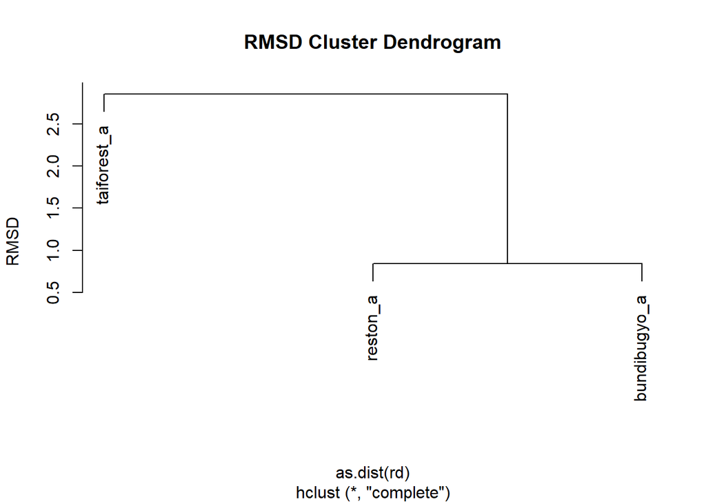

```r
#create a cluster via the distance between groups in the RMSD
#global
hc <- hclust(as.dist(rd))

#plot the cluster created above
plot(hc, ylab = "RMSD", main = "RMSD Cluster Dendrogram")
```

# **Analysis of Results**

The tall letters that appear on the sequence logos represent sequence conservation. As such, the more tall letters there are in my comparison logos, the more similar the two ebolaviruses are. If you were to count the amount of conserved letters between my comparisons, would discover that: * tai forest and bundibugyo share 42 nucleotides *(and are thus most similar)* * bundibugyo and reston share 39 nucleotides * tai forest and reston share 32 nucleotides *(and are thus the most dissimilar)* Based on this, can determine that according to the short nucleotide sequence from position 397 to 468 of the three ebolaviruses, Tai Forest and Bundibugyo would cluster together as the most similar ebolaviruses. This supports my hypothesis - the sequences of Tai Forest and Bundibugyo are more similar to each other than to Reston.

However, when looking at the RMSD values of the protein structures of chain A of the nucleoproteins, the hierarchical cluster depicts that the Reston and the Bundibugyo ebolaviruses are more similar, which is against my hypothesis.

I would say that overall, it is hard to come to a solid conclusion as to which ebolavirus nucleoproteins are more similar due to the contradicting data results. However, it is important to note that both methods were looking at different parts of the nucleoprotein and in different lengths.